# Online learning

## Sequential decision making

Periodic decision making by evaluating a dynamic phenomena and acting appropriately, often under uncertainty.

- Inventory management
- Internet recommendation systems
- Dynamic pricing
- Internet advertisement placement

## Inventory management

- We study stochastic inventory planning with lost sales and instantaneous replenishment.
- We observe only the sales quantity in each period, and lost sales are unobservable, that is, demand data are censored.
- The manager must make an ordering decision at the beginning of each period based only on historical sales data.
- Excess inventory is perishable.

| Case | Distribution | Continuous | Stationary | Solution |
| --- | --- | --- | --- | --- |
| 1 | ✅ | ✅ | ✅ | NV |
| 2 | ❌ | ✅ | ✅ | AIM |
| 3 | ❌ | ❌ | ✅ | AEE |
| 4 | ❌ | ❌ | ❌ | SSRN |

## Newsvendor (NV) [Full Information]

For any $y \geq 0$, the expected one-period cost when the inventory level is $y$, $$Q(y) = hE[y−D]^+ + bE[D−y]^+$$

[figure not shown]

$Q$ achieves its minimum at the newsvendor quantity given by $$y^{NV} = inf \{y \geq 0 | F(y) \geq β \}$$, where $F$ is demand distribution and $β=\frac{b}{b+h}$ is representing a service level.

[figure not shown]

```python
import matplotlib.pyplot as plt
import numpy as np
import sys

class InventoryControl:
    def __init__(self, underage_cost=3, overage_cost=7, max_demand=200, max_t=1000):
        self.overage_cost = overage_cost
        self.underage_cost = underage_cost
        self.max_demand = max_demand
        self.max_t = max_t
        self.beta = self.underage_cost / (self.underage_cost + self.overage_cost) # service level
        self.demand_realization = np.random.randint(low=0.0, high=self.max_demand, size=self.max_t, dtype=int)
        self.demand_cdf = np.asarray([[i, i/max_demand] for i in range(max_demand)])

    def plotRegret(self, yt_dict, y_nv):
        nv_cost = np.maximum(y_nv-self.demand_realization,0)*self.overage_cost + np.maximum(self.demand_realization-y_nv,0)*self.underage_cost
        for label, yt in yt_dict.items():
            yt = np.asarray(yt)
            policy_cost = np.maximum(yt-self.demand_realization,0)*self.overage_cost + np.maximum(self.demand_realization-yt,0)*self.underage_cost
            regret = policy_cost - nv_cost
            c_regret = regret.cumsum()/(np.arange(self.max_t)+1)
            plt.plot(c_regret, '-', label=label)
        plt.xlabel('period')
        plt.ylabel('regret')
        plt.legend()
        plt.grid()
        plt.show()

    def newsVendorSolution(self):
        self.y_nv = self.demand_cdf[:,0][(np.argwhere(self.demand_cdf[:,1]>=self.beta)[:,0]).min()]

underage_cost = 7
overage_cost = 3
max_demand = 200
max_t = 1000

inv_ctrl = InventoryControl(underage_cost=underage_cost,
                            overage_cost=overage_cost,
                            max_demand=max_demand,
                            max_t=max_t
                            )

inv_ctrl.newsVendorSolution()
print(inv_ctrl.y_nv)
```

```
140.0
```

## Regret

$T$-period regret is defined as $$ R_T = \sum_{t=1}^T c(y_t, d_t) - \sum_{t=1}^T c(y^{NV}, d_t)$$

$R_T$ should be sublinear with period $T$ to guarantee convergence.

- Objective, $\lim_{T → ∞} \frac{R_T}{T} = 0$.
- It will happen iff $\frac{R_T}{T}$ is sublinear with $T$ i.e. $ O(T^{\lt 1})$.

## Convergence study

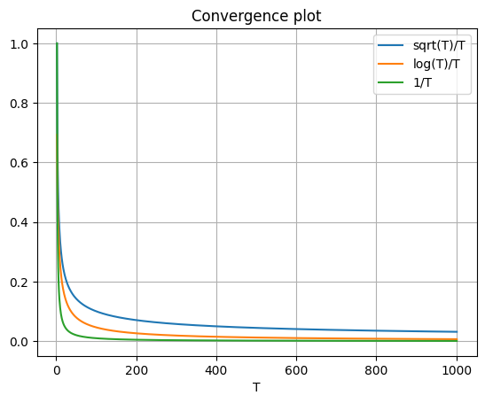

```python
f1 = lambda T : 1/np.sqrt((T-1))
f2 = lambda T : np.log(T)/(T-1)
f3 = lambda T : 1/(T-1)
t = np.linspace(2, 1001, 1000)
plt.plot(t, f1(t), label='sqrt(T)/T')
plt.plot(t, f2(t), label='log(T)/T')
plt.plot(t, f3(t), label='1/T')
plt.xlabel('T')
plt.title('Convergence plot')
plt.grid()
plt.legend()
plt.show()
```

## Follow The Leader

Optimal solution till time $t$, $$y_t^* = \min_{y \in I} ∑_{i=1}^{t-1} c(y,d_i)$$

## Online Convex Optimization

```
Input: A convex set S, convex cost c.
for t = 1,2,...
    predict yt ∈ S
    receive true answer dt ∈ I
    suffer a cost c(yt,dt) = h*max([yt-dt],0) + b*max([dt-yt],0)
```

## Online Gradient Descent (OGD)

**parameter**: $η \gt 0$

**initialize**: $y_t = 0$

**update rule**: $y_{t+1} = y_{t} - ηz_t$ where $ z_t=∂c_t(y_t)$

## Adaptive Inventory Management (AIM)

**Nuances**: Knowledge of the demand distribution is not available.

**Assumption**: An upper bound $\bar{y}$ on the newsvendor quantity $y^{NV}$ is known.

**Algorithm**: AIM maintains the following sequence:

- $({y_t} : t \geq 1)$: Represents actual implemented invnetory levels after ordering.

Set $y_1$ to any value in $[0, \bar{y}]$. For $t \geq 1$, the two sequences are recursively defined as follows

- $y_{t+1} = P_{[0,\bar{y}]} (y^t - η_t H_t ( y_t))$

where, $H_t ( y_t) = h$ if $D_t \lt y_t$ otherwise $-b$.

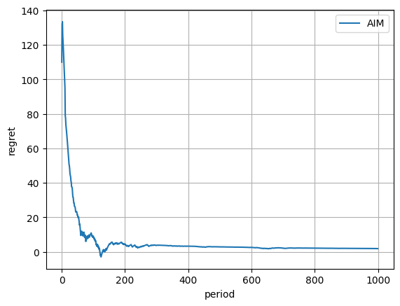

```python
def AIMSolution(self):
    yt_aim = [0]
    for t,dt in enumerate(self.demand_realization[:-1]):
        # dt = dt # uncensored demand
        dt = min(dt, yt_aim[-1]) # censored demand
        a = 0.1
        e = a*self.max_demand/(max(self.underage_cost,self.overage_cost)*((t+1)**0.5))
        if dt<yt_aim[-1]:
            yt_aim.append(yt_aim[-1]-e*self.overage_cost)
        else:
            yt_aim.append(yt_aim[-1]+e*self.underage_cost)
    return yt_aim

yt_aim = AIMSolution(inv_ctrl)
inv_ctrl.plotRegret({'AIM':yt_aim}, inv_ctrl.y_nv)
```

## Alternating Exploration and Exploitation (AEE)

**Nuances**: Works for both discreate and continuous demand.

**Assumption**:

1. Optimal order quantity is bounded i.e. $y^{NV} \leq M$.
2. Objective function is strictly convex if demand is continuous.
3. Minimal separation around optimal quantity must be there in case of discreate demand.

**Explanation**

[figure not shown]

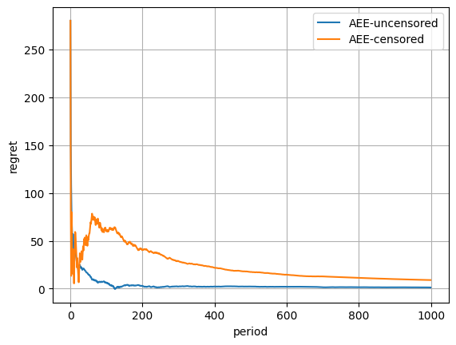

```python
def getBetaQuantileUncensored(sample_demand, max_demand, beta):
    sample_length = len(sample_demand)
    for k in range(max_demand):
        emperical_beta = len(np.argwhere(sample_demand<=k)[:,0])/sample_length
        if emperical_beta>=beta:
            return k
    return max_demand

def getBetaQuantileCensored(demand_list, beta, optimal_qty):
    censored_demand = np.where(demand_list<=optimal_qty, demand_list, optimal_qty)
    estimated_beta_quantile = getBetaQuantileUncensored(censored_demand, max_demand, beta)
    return estimated_beta_quantile

# Algorithm-1: Demand is known., uncensored demand.
def getOrderQuantity(self):
    ordered_qty = []
    ordered_qty.append(self.max_demand//2) # at t=0, start with random quantity. As we realize the demand, ordered_qty should converge to optimal.

    # iterate through time period
    for t in range(1,self.max_t):
        xt = getBetaQuantileUncensored(self.demand_realization[:t], self.max_demand, self.beta)
        ordered_qty.append(xt)
    return ordered_qty

def exploreStrategy(self):
    optimal_quantity_so_far = self.max_demand/2
    step = 100
    delta = 20
    ordered_qty = []

    for t in range(0,self.max_t,step):
        ordered_qty+=[optimal_quantity_so_far for i in range(step)]
        explore_quantile = getBetaQuantileCensored(self.demand_realization[t:t+step], self.beta, optimal_quantity_so_far+delta)
        optimal_quantity_so_far += (explore_quantile - optimal_quantity_so_far)*0.3
    return ordered_qty

yt_aee_uncensored = getOrderQuantity(inv_ctrl)
yt_aee_censored = exploreStrategy(inv_ctrl)
inv_ctrl.plotRegret({'AEE-uncensored':yt_aee_uncensored,
                     'AEE-censored':yt_aee_censored},
                    inv_ctrl.y_nv)
```

## SSRN

**Nuances**: Demand for a product may very well be nonstationary.

**Exponentially Weighted Forecaster (EWF)**:

- At the end of the period, the firms incurs a cost $c(y_t,d_t) = h(y_t-d_t)^+ + b(d_t-y_t)^+$.
- Cumulative cost is defined as $C_y(t) = C_y(t-1) + c(y,d_t), ∀ y \in I$.
- Let, $W_y(t) = e^{-η C_y(t)}$ and $W(t) = \sum_{y \in I} W_y(t)$.
- From recursive relation, $W_y(t) = W_y(t-1)e^{-η c(y,d_t)}$.
- EWF policy chooses inventory $y_t$ with probability $$p_y(t) = (1-γ)\frac{W_y(t-1)}{W(t-1)} + \frac{γ}{N}, ∀y \in I$$.

**Explaination**: This algorithm chooses an arm at random with probability $(1-γ)$ it prefers arms with higher weights (exploit), it chooses with probability $γ$ to uniformly randomly explore. After receiving the rewards the weights are updated. The exponential decay significantly decreases the weight of bad arms.

**Fixed-Share Forecaster (FSF)**: The weight update rule is modified as, $$W_y(t) = W_y(t-1)e^{-ηc(y,d_t)} + \frac{α}{N} \sum_{i \in I} W_i(t-1)\$$

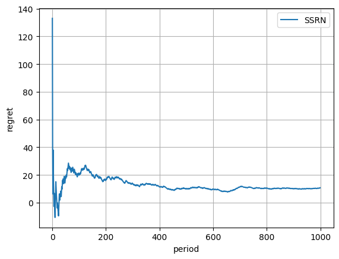

```python
def ssrn(self):
    wt = np.ones(self.max_demand+1)
    arms = np.arange(self.max_demand+1)
    cost = np.zeros(self.max_demand+1)
    beta = max_demand*max(self.underage_cost, self.overage_cost)
    gamma = 1/(2*beta*self.max_t)
    eta = np.sqrt(np.log(self.max_demand)/(10*(beta**2)*self.max_t*np.log((3*self.max_demand/gamma)+3)))

    yt_ssrn = []
    for k in range(self.max_t):
        pt = (1-gamma)*wt/sum(wt) + (gamma)/(self.max_demand+1)
        at = np.random.choice(arms, size=1, p=pt)[0]

        for i in range(self.max_demand+1):
            cost_vec = []
            Pt = pt[i:].sum()
            for j in range(self.max_demand+1):
                if j<=i:
                    cost_vec.append(self.overage_cost*(i-j+1)-self.underage_cost*(j-1))
                else:
                    cost_vec.append(-self.underage_cost*i)
            if i>at:
                qe = 0
                cost[i] = 0
            else:
                qe = cost_vec[self.demand_realization[k]]
                cost[i] = (qe+beta)/Pt

        wt *= np.exp(-eta*cost)
        yt_ssrn.append(at)

        return yt_ssrn

yt_ssrn = ssrn(inv_ctrl)
inv_ctrl.plotRegret({'SSRN':yt_ssrn,}, inv_ctrl.y_nv)
```

## Conclusion

A summary of results regarding the minimax optimal scaling of the regret in the repeated newsvendor problem with demand learning via censored data, with respect to the number of time periods, $T$.

[output not shown]

## References

1. [Online Learning and Online Convex Optimization](https://www.cs.huji.ac.il/~shais/papers/OLsurvey.pdf)
2. [A Non-Parametric Asymptotic Analysis of Inventory Planning with Censored Demand](http://www.columbia.edu/~th2113/files/DataLostSales-MOR-2008Oct-1.pdf)
3. [On Implications of Demand Censoring in the Newsvendor Problem](https://www0.gsb.columbia.edu/mygsb/faculty/research/pubfiles/3596/besbes_newsvendor_problem.pdf)
4. [On the Hardness of Learning from Censored Demand](https://papers.ssrn.com/sol3/papers.cfm?abstract_id=3509255)